# HW 2 EDAV

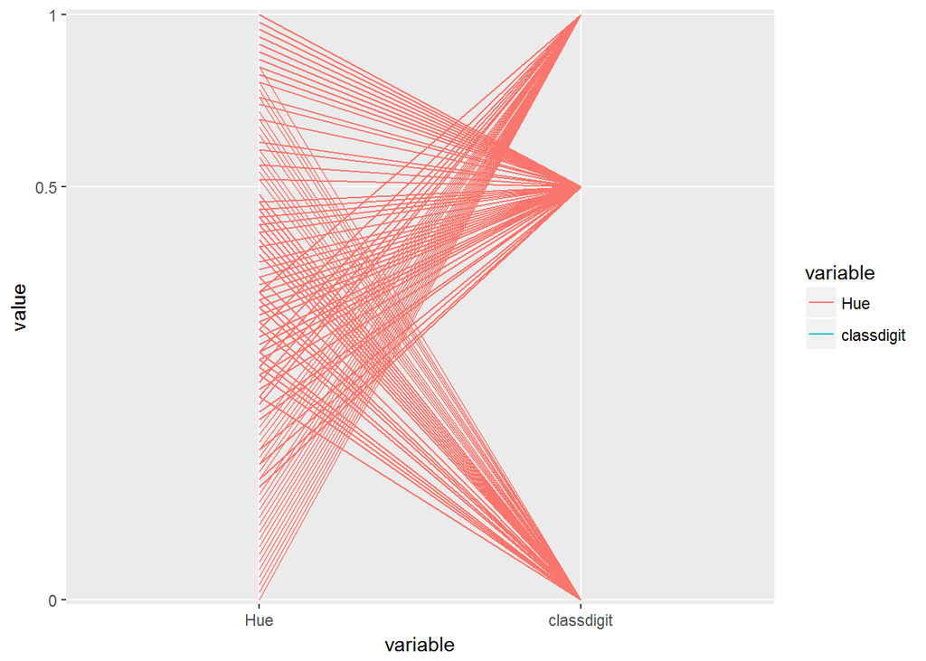

```r
ggplot(wine_tidy[wine_tidy$variable=="classdigit" | wine_tidy$variable=="Hue",], aes(variable, value, group = id,color=variable)) + geom_line()+ scale_y_discrete(breaks=c("0","0.5","1"))
```

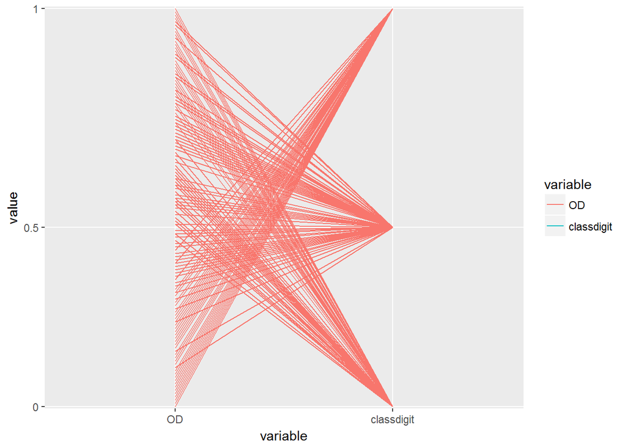

```r
ggplot(wine_tidy[wine_tidy$variable=="classdigit" | wine_tidy$variable=="OD",], aes(variable, value, group = id,color=variable)) + geom_line()+ scale_y_discrete(breaks=c("0","0.5","1"))
```

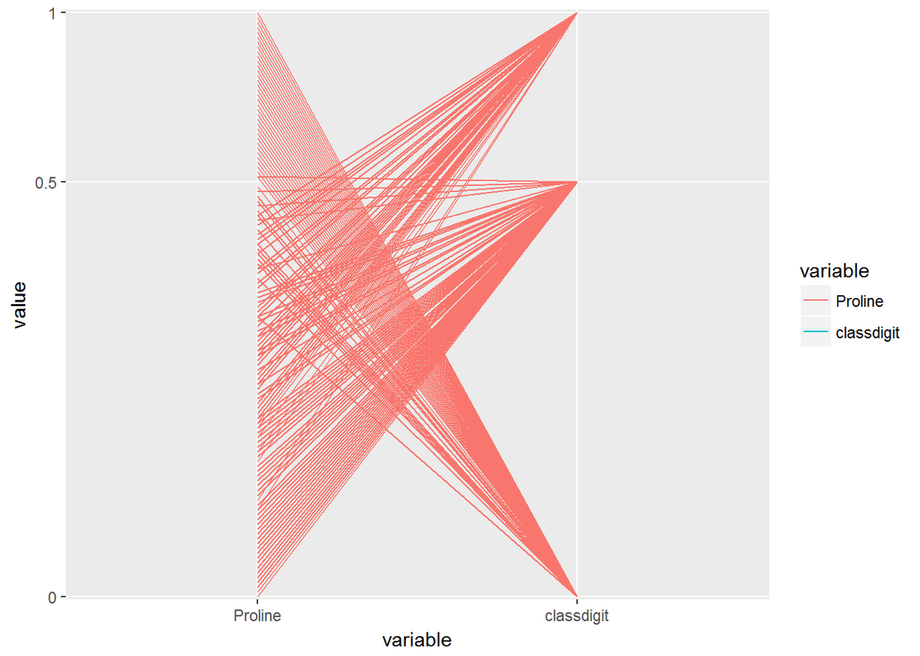

```r
ggplot(wine_tidy[wine_tidy$variable=="classdigit" | wine_tidy$variable=="Proline",], aes(variable, value, group = id,color=variable)) + geom_line()+ scale_y_discrete(breaks=c("0","0.5","1"))
```

Plotted the PCP individually for each variable so that they are readable (a) We can infer if the variables separate the classes by looking at PCP and seeing if the lines for the three classes originate from/lead to different values of a variable. Eg. for variable Flav, we can see that for class=3 (value=1 in the PCP), Flav values are on the lower side. For class=1, the values are on the higher side and for class=2 they tend to lie in the middle. There are very few variables which separate all the three classes well. There are some variables which separate two of the three classes well. Following are those variables:

**separate all three classes:** Flav, Color

**Only separate class 1 and 2:** Alcohol, Proline

**Only separate class 1 and 3:** AlcAsh, Phenols, Proa, Hue, OD, Proline

**Only separate class 3 and 2:** Alcohol

2. Yes, there are many outliers which can be seen from the lines originating from values close to 1 and 0. These lines stand out by their own and hence, are outliers.
3. Yes, there is evidence of subgroups within classes. This can be seen from the individual PCP for all variables. Some variables take wide range of values for all classes and hence, can’t separate them well. Thus, we can form subgroups within classes based on the value of such variables.

## Part 2

# Dataset 1: Whiskey

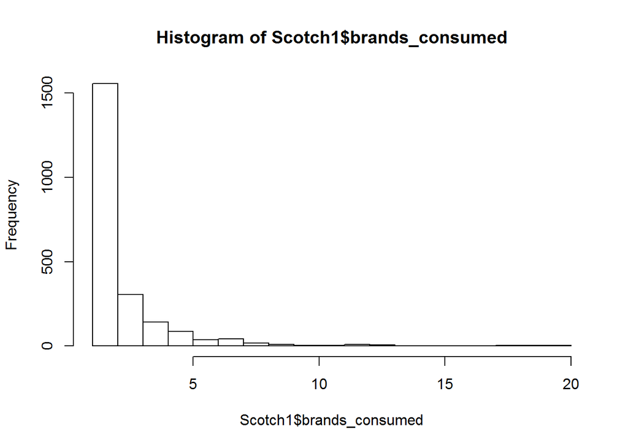

```r
data(Scotch)
brands_consumed=array(dim=length(Scotch[,1]))
for (i in 1:length(brands_consumed)){
  brands_consumed[i]=sum(Scotch[i,])
}

Scotch1=Scotch
Scotch1$brands_consumed=brands_consumed
hist(Scotch1$brands_consumed,breaks=20)
```

This histogram shows how many brands a single user bought. We see that people usually buy the same brand. I did more analysis on this below.

```r
library(arules)
Scotch1=Scotch
for (i in 1:length(colnames(Scotch))){
  Scotch1[,i]=as.logical(Scotch[,i])
}
rules <- apriori(Scotch1,parameter = list(supp=0.01,conf=0.1,minlen=2,maxlen=2))
```

```
## Apriori
##
## Parameter specification:
##  confidence minval smax arem  aval originalSupport maxtime support minlen
##         0.1    0.1    1 none FALSE            TRUE       5    0.01      2
##  maxlen target   ext
##       2  rules FALSE
##
## Algorithmic control:
##  filter tree heap memopt load sort verbose
##     0.1 TRUE TRUE  FALSE TRUE    2    TRUE
##
## Absolute minimum support count: 22
##
## set item appearances ...[0 item(s)] done [0.00s].
## set transactions ...[21 item(s), 2218 transaction(s)] done [0.00s].
## sorting and recoding items ... [21 item(s)] done [0.00s].
## creating transaction tree ... done [0.00s].
## checking subsets of size 1 2 done [0.00s].
## writing ... [166 rule(s)] done [0.00s].
## creating S4 object  ... done [0.00s].
```

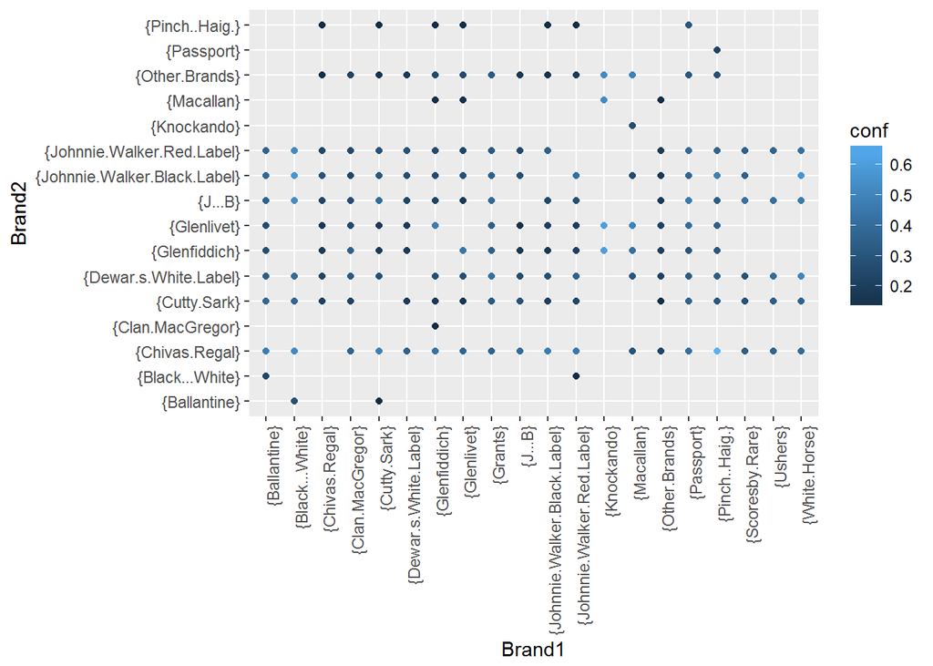

```r
#inspect(rules)
#Copied the rules into excel sheet and imported the data
library(readr)
association <- read_csv("G:/Acads/EDAV/association.csv")
#View(association)
ggplot(data=association,aes(Brand1,Brand2,color=conf))+geom_point()+theme(axis.text.x = element_text(angle = 90, hjust = 1))
```

This plot shows how different brands are associated with each other. The intensities of the dots show the confidence for the pair.

Confidence = Prob(Brand on Y axis was bought| Brand on X axis was bought)

Confidence tells the likelihood of a person buying Brand on Y axis given that he bought the brand on X axis. Dark blue implies low association and hence, the brands not being bought by the same people. Opposite is true for Light blue. We can clearly see group of brands emerging from this.

**{Glenlivet, Glenfidditch, Knockonda}**: These brands have high association within themselves and have low association with all other brands. Interesting thing is all these are single malts, implying customers sticking to a single type of whiskey (in this case single malt) rather than a single brand. We can add **Macallan** as well to this group due to high association. And interestingly, it also a single malt.

**Chivas Regal**: When we look at Chivas Regal on Y-axis, we see high associations with lot of brands. This implies that customer who buy any kind of whiskey, frequently buy Chivas Regal as well. But, the opposite is not true. People who buy Chivas Regal(On X axis), stick to Chivas Regal. Chivas Regal could probably be a brand which has a wide audience and a strong following from certain people who stick to it.

**Johnnie Walker(both brands), J&B, Black&White** can also be said to be forming a group.

# Dataset 2: Wine

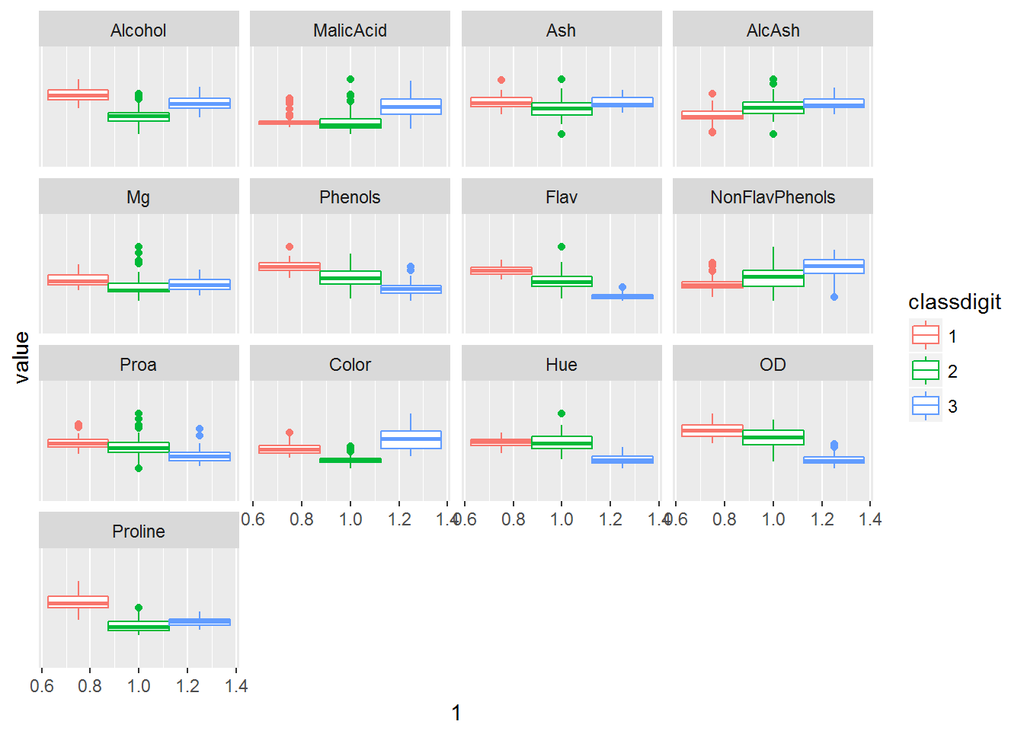

```r
wine1=wine
for (i in 1:13){
  max=max(wine1[,i])
  min=min(wine1[,i])
  wine1[,i]=(wine1[,i]-min)/(max-min)
}

wine2<-wine1[,-c(ncol(wine1))]

# Plotting inidividual pcp for each variable so that it can be read well
wine_tidy <- melt(wine2, id=c("classdigit"))
ggplot() + geom_boxplot(data=wine_tidy, aes(y=value,x=1,color=classdigit)) + scale_y_discrete(breaks=c("0","0.5","1"))+facet_wrap(~variable)
```

This plot visualizes the boxplot of the variable value for the three classes. As compared to PCP, this is a lot easier way to visually tell which variables separate the classes well. Good thing about boxplot for this task is that we can ignore the outliers. But, in PCP it is difficult to make out outliers if there are too many of them.

**Separate all three classes:** Phenols, Flav, Color, NonFlavPhenols, Alcohol

**Only separate class 1 and 2:** Proline, Ash, Mg

**Only separate class 1 and 3:** Malic Acid, AlcAsh, Proa, Hue, OD, Proline

**Only separate class 3 and 2:** Malic Acid, Hue, OD

Above list is based on comparing if the middle 50% range overlaps for two different classes. I am more confident about this list than the one we got using PCP because PCP is very difficult to read. We also have some new variables in this list as compared to the one we got from PCP.

I then built a model using the 5 variables which could separate all the three classes well and got an **accuracy of 94%**. We can also say that these boxplots have helped us in heuristically finding out important variables and using them for the model. On using five of the less predictive variables, the accuracy drops to 84%

```r
library(nnet)
wine$prog2 <- relevel(wine$classdigit, ref = 1)
test <- multinom(prog2 ~ Phenols + Flav+Color + NonFlavPhenols + Alcohol, data = wine)
#summary(test)

wine_pred=wine
predictions=predict(test, newdata = wine_pred, "probs")

for (i in 1:length(predictions[,1])){
  max=max(predictions[i,])
  for (j in 1:3){
    if (max==predictions[i,j]){
      wine_pred$pred[i]=j
    }
  }
}

sum=0
wine_pred$classdigit=as.numeric(wine_pred$classdigit)
for (i in 1:length(predictions[,1])){
  if (wine_pred$classdigit[i]==wine_pred$pred[i]){
    sum=sum+1
  }
}


Accuracy1=sum/length(predictions[,1])


#Malic Acid, AlcAsh, Proa, Hue, OD, Proline, Ash Mg
test <- multinom(prog2 ~ MalicAcid+ AlcAsh+ Proa+ Hue+ OD, data = wine)
summary(test)
```

```
## Call:
## multinom(formula = prog2 ~ MalicAcid + AlcAsh + Proa + Hue +
##     OD, data = wine)
##
## Coefficients:
##   (Intercept)  MalicAcid    AlcAsh        Proa        Hue         OD
## 2    1.464238 -0.2797695 0.4795509  -0.3209632  -1.427318  -2.536592
## 3   69.936594  2.9635648 4.3637329 -22.5032239 -79.414885 -35.776488
##
## Std. Errors:
##   (Intercept) MalicAcid    AlcAsh      Proa       Hue        OD
## 2    2.958349 0.2880139 0.1025067 0.4357562  1.486148 0.6495112
## 3   10.800134 1.5404555 1.1437832 5.6157451 10.898881 5.6099035
##
## Residual Deviance: 119.4771
## AIC: 143.4771
```

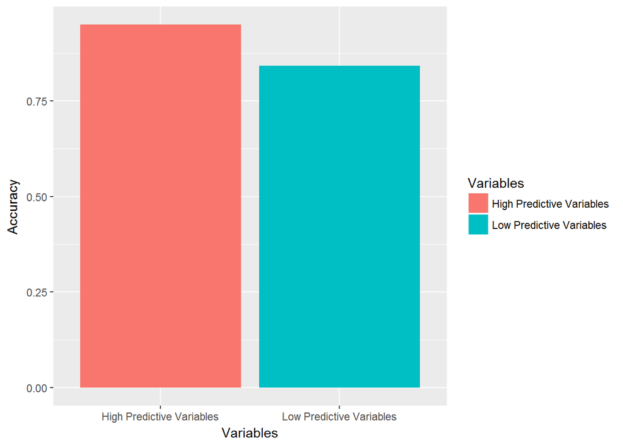

```r
wine_pred=wine
predictions=predict(test, newdata = wine_pred, "probs")

for (i in 1:length(predictions[,1])){
  max=max(predictions[i,])
  for (j in 1:3){
    if (max==predictions[i,j]){
      wine_pred$pred[i]=j
    }
  }
}

sum=0
wine_pred$classdigit=as.numeric(wine_pred$classdigit)
for (i in 1:length(predictions[,1])){
  if (wine_pred$classdigit[i]==wine_pred$pred[i]){
    sum=sum+1
  }
}

Accuracy2=sum/length(predictions[,1])

Variables=c('High Predictive Variables','Low Predictive Variables')
Accuracy=c(Accuracy1,Accuracy2)
data_acc=data.frame(Variables,Accuracy)

ggplot(data=data_acc,aes(Variables,Accuracy,fill=Variables))+geom_bar(stat='identity')
```